# SEA tfMRI - Within-person, Internal Consistency: Parcel 196

John Flournoy

2021-03-26

```r
library(data.table)
library(brms)
```

```r
library(ggplot2)
library(argparse)
library(e1071)
library(patchwork)
library(showtext)
#{.tabset}

font_add_google("Didact Gothic", "Didact Gothic")

knitr::opts_chunk$set(echo = TRUE, message = FALSE, warning = FALSE)
#https://www.instagram.com/p/CC3EvmLgt2m/?utm_source=ig_web_copy_link
apal <- paste0('#',c('2C2B2B', 'F9773B', 'FFEA8C', '1389E6', 'D2E5E7'))
jftheme <- theme_minimal() +
    theme(text = element_text(family = 'Didact Gothic', size = 14),
          panel.background = element_rect(fill = apal[[5]], size = 0, color = apal[[2]]),
          panel.grid.major = element_blank(),
          panel.grid.minor = element_blank(),
          strip.background = element_rect(fill = apal[[3]], size = 0),
          strip.text = element_text(color = '#222222'),
          axis.text =  element_text(color = apal[[1]]), axis.title = element_text(color = apal[[1]]))


# stat: skew
skew <- function(x) {
  xdev <- x - mean(x)
  n <- length(x)
  r <- sum(xdev^3) / sum(xdev^2)^1.5
  return(r * sqrt(n) * (1 - 1/n)^1.5)
}

parser <- ArgumentParser(description='Viz within-person alpha')
parser$add_argument('--subsample', action = 'store_true', help = 'run the model with 15 randomly selected voxels (sampled within person-sessions)')
# args <- parser$parse_args(c('--moresamples'))
args <- parser$parse_args()

SUBSAMP <- args$subsample

if(SUBSAMP){
  suffix <- '-sub'
} else {
  suffix <- ''
}

setDTthreads(5)

task_id <- as.numeric(Sys.getenv('SLURM_ARRAY_TASK_ID'))

if(is.na(task_id)){
  this_ROI <- 196 #TO BE SET BY SLURM ENV VAR
  message('Not running as slurm array, setting ROI to some value: ', this_ROI)
} else {
  this_ROI <- task_id
  message('Running as slurm array with task id=ROI: ', task_id, '=', this_ROI)
}
```

```
## Not running as slurm array, setting ROI to some value: 196
```

> Nezlek, J. B. (2017). A practical guide to understanding reliability in studies of within-person variability. Journal of Research in Personality, 69, 149–155. https://doi.org/10.1016/j.jrp.2016.06.020

$$\begin{aligned}
\text{Voxels: } y_{ijk} &= \pi_{0jk} + \epsilon_{ijk}\\
\text{Occasions: } \pi_{0jk} &= \beta_{00k} + \rho_{0jk}\\
\text{Persons: } \beta_{00k} &= \gamma_{000} + \nu_{00k}\\
\\
\text{Combined: } y_{ijk} &= \gamma_{000} + \nu_{00k} + \rho_{0jk} + \epsilon_{ijk}\\
\end{aligned}$$

Voxel-level reliability for a parcel:

$$\alpha = \frac{\tau_\pi}{\tau_\pi + \frac{\sigma^2}{j}}$$

where $\tau_\pi$ indicates the variance of the random component of the parameter $\pi$, $\sigma^2$ is the variance of the error term $\epsilon_{ijk}$, and $j$ is the number of voxels.

Important caveat:

> Perhaps more important, similar to the assumptions made when using Cronbach’s alpha, the items are assumed to be parallel. According to Shrout and Lane (2012) this means that “(a) Items must be replicate indicators of the same underlying latent trait, (b) responses to the items must be independent after adjusting for the level of the latent trait, and (c) the magnitude of error associated with each item must be the same.”

In addition, the consistency among voxels within a parcel will be elevated by smoothing. That's precisely the reason for doing smoothing in the first place: to average out, over space, residual error.

```r
file_search_regex <- paste0('alpha-fearGTcalm-ROI', this_ROI, '(-more_\\d{2})*', suffix, '.rds')

roi_fits <- dir('fits', pattern = file_search_regex, full.names = TRUE)
fits <- lapply(roi_fits, readRDS)

cfit <- brms::combine_models(mlist = fits)
```

# Model summary

## Posterior summary

```r
summary(cfit)
```

```
##  Family: student
##   Links: mu = identity; sigma = identity; nu = identity
## Formula: y ~ (1 | id/sess)
##    Data: NULL (Number of observations: 72416)
## Samples: 8 chains, each with iter = 5000; warmup = 1000; thin = 1;
##          total post-warmup samples = 32000
##
## Group-Level Effects:
## ~id (Number of levels: 30)
##               Estimate Est.Error l-95% CI u-95% CI Rhat Bulk_ESS Tail_ESS
## sd(Intercept)     0.07      0.05     0.00     0.17 1.03      203      720
##
## ~id:sess (Number of levels: 292)
##               Estimate Est.Error l-95% CI u-95% CI Rhat Bulk_ESS Tail_ESS
## sd(Intercept)     0.76      0.03     0.70     0.82 1.01      984     1789
##
## Population-Level Effects:
##           Estimate Est.Error l-95% CI u-95% CI Rhat Bulk_ESS Tail_ESS
## Intercept     0.00      0.05    -0.09     0.10 1.02      439      968
##
## Family Specific Parameters:
##       Estimate Est.Error l-95% CI u-95% CI Rhat Bulk_ESS Tail_ESS
## sigma     0.48      0.00     0.47     0.48 1.00    14807    17999
## nu        4.47      0.08     4.32     4.64 1.00    14193    17565
##
## Samples were drawn using sampling(NUTS). For each parameter, Bulk_ESS
## and Tail_ESS are effective sample size measures, and Rhat is the potential
## scale reduction factor on split chains (at convergence, Rhat = 1).
```

## Prior summary

```r
prior_summary(cfit)
```

```
##                 prior     class      coef   group resp dpar nlpar bound
##  student_t(3, 0, 2.5) Intercept
##         gamma(2, 0.1)        nu
##       normal(0, 0.25)        sd
##       normal(0, 0.25)        sd                id
##       normal(0, 0.25)        sd Intercept      id
##       normal(0, 0.25)        sd           id:sess
##       normal(0, 0.25)        sd Intercept id:sess
##  student_t(3, 0, 2.5)     sigma
##        source
##       default
##       default
##          user
##  (vectorized)
##  (vectorized)
##  (vectorized)
##  (vectorized)
##       default
```

# Model diagnostics

```r
np <- nuts_params(cfit)
```

Divergent transitions: 18

## Neff ratio

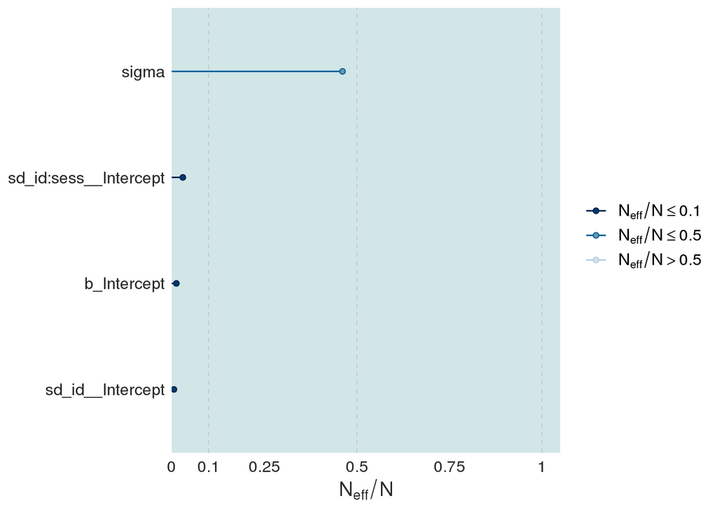

```r
bayesplot::mcmc_neff(brms::neff_ratio(cfit, pars = c('sd_id__Intercept',
                                                     'sd_id:sess__Intercept',
                                                     'b_Intercept', 'sigma'))) +
  jftheme
```

```r
brms::neff_ratio(cfit, pars = c('sd_id__Intercept',
                                'sd_id:sess__Intercept',
                                'b_Intercept'))
```

```
##      sd_id__Intercept sd_id:sess__Intercept           b_Intercept
##           0.006129616           0.030223327           0.012740246
```

## Autocorrelation within-chain

```r
bayesplot::mcmc_acf(cfit, lags = 50, pars = c('sd_id__Intercept',
                                              'sd_id:sess__Intercept',
                                              'b_Intercept', 'sigma')) +
  jftheme
```

[output not shown]

## r-hat

```r
bayesplot::mcmc_rhat(brms::rhat(cfit))
```

[output not shown]

## Trace plot

```r
bayesplot::mcmc_trace(cfit, pars = c('sd_id__Intercept',
                                     'sd_id:sess__Intercept',
                                     'b_Intercept')) +
  jftheme
```

[output not shown]

## Posterior predictive checks

### Density

```r
brms::pp_check(cfit, type = 'dens_overlay')
```

[output not shown]

### ECDF

```r
brms::pp_check(cfit, type = 'ecdf_overlay')
```

[output not shown]

### Skew

```r
brms::pp_check(cfit, nsamples = 1000, type = 'stat', stat = 'skew')
```

[output not shown]

### Kurtosis

```r
brms::pp_check(cfit, nsamples = 1000, type = 'stat', stat = 'kurtosis')
```

[output not shown]

## Divergence Diagnostics

```r
fit_array <- as.array(cfit)
bayesplot::color_scheme_set("darkgray")
```

### Parcoord

```r
bayesplot::mcmc_parcoord(fit_array, np = np, pars = c('sd_id__Intercept',
                                                      'sd_id:sess__Intercept',
                                                      'b_Intercept'),
                         np_style = bayesplot::parcoord_style_np(div_color = "red", div_size = .5, div_alpha = 1))
```

[output not shown]

### Pairs plots

```r
bayesplot::mcmc_pairs(fit_array, np = np, pars = c('sd_id__Intercept',
                                                   'sd_id:sess__Intercept',
                                                   'b_Intercept'),
                      off_diag_fun = c("hex"),
                      # off_diag_args = list(size = 0.75),
                      condition = bayesplot::pairs_condition(),
                      # transform = list('sd_id__Intercept' = 'log',
                      #                  'sd_id:sess__Intercept' = 'log'),
                      np_style = bayesplot::pairs_style_np(div_size = 4))
```

[output not shown]

### Chains

```r
window <- range(which(np$Value[np$Parameter == 'divergent__'] == 1) %% 4000)
if(window[[1]] == Inf){
  cat('No divergences')
} else {
  bayesplot::mcmc_trace(fit_array, pars = "sd_id__Intercept", np = np, window = window) +
    xlab("Post-warmup iteration")
  bayesplot::mcmc_trace(fit_array, pars = "sd_id:sess__Intercept", np = np, window = window) +
    xlab("Post-warmup iteration")
  bayesplot::mcmc_trace(fit_array, pars = "b_Intercept", np = np, window = window) +
    xlab("Post-warmup iteration")
}
```

[output not shown]

### Log-posterior

```r
lp <- log_posterior(cfit)
bayesplot::mcmc_nuts_divergence(np, lp)
```

[output not shown]

# Parameters of interest

## Variance parameters

```r
bayesplot::mcmc_areas_ridges(fit_array, pars = c('sd_id__Intercept',
                                                 'sd_id:sess__Intercept'), prob = .95, prob_outer = .99) +
bayesplot::mcmc_areas(fit_array, pars = c('sigma'), prob = .95, prob_outer = .99)
```

[output not shown]

## Internal consistency

### Posterior Summary

```r
vc <- VarCorr(cfit, summary = FALSE)
# alpha_model_fit
tau_pi <- vc$`id:sess`$sd^2
tau_beta <- vc$id$sd^2
sigma2 <- vc$residual__$sd^2
nvoxel <- length(cfit$data$y)/dim(unique(cfit$data[, c('sess', 'id:sess')]))[[1]]
alpha_post <- tau_pi / (tau_pi + sigma2/nvoxel)
pvar <- tau_pi / (tau_pi + tau_beta + sigma2)
post_df <- data.frame(alpha = alpha_post[,1], prop_var = pvar[,1])

knitr::kable(posterior_summary(post_df, robust = TRUE), digits = 3)
```

[output not shown]

### Posterior plot

```r
bayesplot::mcmc_areas(post_df, pars = 'alpha', prob = .95, prob_outer = .99, point_est = 'median') +
  bayesplot::mcmc_areas(post_df, pars = 'prop_var', prob = .95, prob_outer = .99, point_est = 'median')
```

[output not shown]